# Molecular Transitions and Spectroscopy

Author

Daniel Fischer

# Introduction

Having established how molecular energy levels arise from **electronic, vibrational, and rotational degrees of freedom**, we now turn to how these quantized states interact with **electromagnetic radiation**. Absorption or emission of photons allows molecules to transition between these energy levels, providing a direct window into **molecular structure, bonding, and dynamics**.

While electronic transitions probe the **fast motion of electrons**, vibrational and rotational transitions probe the **slower motion of nuclei**. For diatomic molecules, this separation of timescales makes the system especially transparent: nuclear motion reduces to a single **internuclear coordinate** $R$ with associated rotational and vibrational motions superimposed on the electronic structure.

Within this framework, **molecular spectroscopy** becomes the study of **transition rates and selection rules** governing the allowed changes in vibrational, rotational, and electronic states. Infrared (IR) spectroscopy detects transitions due to changes in a molecule’s **permanent dipole moment**, whereas **Raman spectroscopy** probes changes in the **molecular polarizability**. Together, these complementary techniques provide a comprehensive picture of molecular vibrations and rotations, even for molecules with high symmetry or no permanent dipole moment.

### Goals of this Chapter

By the end of this chapter, you should be able to:

1. Explain how **molecular transitions** arise from the interaction of molecules with electromagnetic radiation.
2. Derive the **transition dipole moment** and understand its decomposition into electronic and nuclear contributions.
3. Apply **selection rules** to predict allowed vibrational, rotational, and electronic transitions.
4. Describe the **structure of rovibrational spectra**, including P- and R-branches.
5. Distinguish between **IR and Raman spectroscopy**, and understand the role of permanent dipoles and polarizability.
6. Appreciate the **practical relevance** of rovibrational transitions, from molecular identification to environmental phenomena like the greenhouse effect.

This chapter provides the **quantitative and qualitative tools** needed to interpret molecular spectra and connect them to **underlying quantum mechanical motion**.

# 1. Transition Rates and Selection Rules

The interaction of a molecule with electromagnetic radiation allows it to **change energy states**, with the rate of these transitions governed by quantum mechanics. For a molecule initially in state $| \Psi_i \rangle$ and finally in state $| \Psi_k \rangle$, the **transition probability** is determined by the **electric dipole operator** $\hat{\vec \mu}$:

$$M_{ik} = \langle \Psi_k | \hat{\vec{\mu}} | \Psi_i \rangle.$$

This **transition dipole matrix element** encapsulates the likelihood of the transition: if $M_{ik}=0$, the transition is forbidden; if $M_{ik}\neq0$, the transition is allowed and its intensity depends on $|M_{ik}|^2$.

The **spontaneous emission rate** is then given by the Einstein coefficient:

$$A_{ik} = \frac{2\omega_{ik}^3}{3\varepsilon_0 c^3 \hbar} |M_{ik}|^2,$$

where $\omega_{ik} = (E_k - E_i)/\hbar$ is the transition frequency. In the following sections, we will **decompose the transition dipole** into electronic and nuclear contributions, and explore how **selection rules** arise for electronic, vibrational, and rotational transitions.

# 1.1 Complete decomposition of the transition dipole

The fundamental quantity that controls spectroscopic intensity is the transition dipole moment $M_{ik}=\langle\Psi_k|\hat{\vec\mu}|\Psi_i\rangle$, with the total dipole operator
$$\hat{\vec\mu} \;=\; -e\sum_{\text{electrons}} \vec r_i \;+\; e\sum_{\text{nuclei}} Z_A \vec R_A
\;=\;\hat{\vec\mu}_{\rm el} + \hat{\vec\mu}_N.$$

Within the Born–Oppenheimer approximation, the total molecular wavefunction can be written as $\Psi(\mathbf r, {\mathbf R}) = \Phi(\mathbf r; {\mathbf R}),\chi({\mathbf R})$, where $\mathbf r$ denotes all electronic coordinates $\vec r_i$ and $\mathbf R$ all nuclear positions ${\vec R_A}$. For a diatomic molecule, the nuclear geometry is determined by a single vector $\vec R = \vec R_2 - \vec R_1$ (or equivalently its length $R$), so the wavefunction simplifies to $\Psi(\mathbf r, R) = \Phi(\mathbf r; R),\chi(R)$. Using this ansatz, the matrix element separates into an inner electronic integral and an outer nuclear integral. For a transition between two states that (possibly) differ in electronic, vibrational and rotational quantum numbers one obtains the standard decomposition:

$$M_{ik}
= \int d^3R\; \chi_k^*(R)\,\rho_{ik}(R)\, \chi_i(R)
\;+\; \int d^3R\; \chi_k^*(R)\;
\bigg[\langle\Phi_k|\hat{\vec\mu}_N|\Phi_i\rangle_{\mathbf r}\bigg]\;\chi_i(R),$$

where the electronic transition dipole (at fixed nuclear geometry) is

$$\rho_{ik}(R)\;=\;\langle\Phi_k(\mathbf r;R)|\hat{\vec\mu}_{\rm el}|\Phi_i(\mathbf r;R)\rangle_{\mathbf r}
\;=\;\int d^3\mathbf r\;\Phi_k^*(\mathbf r;R)\,\hat{\vec\mu}_{\rm el}\,\Phi_i(\mathbf r;R).$$

Two remarks:  
- $\langle\cdots\rangle_{\mathbf r}$ means integrate over electronic coordinates only (parametric dependence on $R$ remains).  
- The first term is the **electronic contribution weighted by nuclear overlap**; the second involves the nuclear dipole operator and overlaps of electronic states (often zero unless the electronic states are the same).

> *Note:* If the coordinate origin is placed at the **center of nuclear charge**, the **expectation value** of the nuclear dipole vanishes for the equilibrium geometry. For this reason, the nuclear term is often omitted in textbooks, though it is implicitly included through the choice of coordinates.

## 1.2 Useful limits and how they produce observed spectra

From the single formula above one obtains the familiar spectroscopic cases by taking the appropriate limits.

### (A) Electronic transitions ($i$ and $k$ different electronic states)

The dominant contribution arises from the first term, where $\rho_{ik}(R)\neq 0$. The outer integral

$$\int d^3R\; \chi_k^*(R)\,\rho_{ik}(R)\,\chi_i(R)$$

represents the **electronic transition dipole moment** averaged over the vibrational wavefunctions of the two electronic states. The resulting overlap integrals determine the **Franck–Condon factors**, which govern the relative intensities of vibronic transitions.

These factors express the **Franck–Condon principle**: because electronic motion is much faster than nuclear motion, electronic transitions occur essentially at fixed internuclear distance. As a result, the most intense transitions connect vibrational levels whose wavefunctions overlap most strongly at the same nuclear geometry.

[figure not shown]

Figure 1: Franck–Condon diagram illustrating electronic transitions between two potential energy curves of a diatomic molecule. Vertical arrows indicate the most probable transitions corresponding to the Franck–Condon principle.  
*(Image credit: Samoza, [CC BY-SA 3.0](https://creativecommons.org/licenses/by-sa/3.0/), [source file](https://commons.wikimedia.org/wiki/File:Franck_Condon_Diagram.svg))*

**NoteSelection Rules for Electronic Transitions**

Electric dipole–allowed **electronic transitions** in diatomic molecules must satisfy:

- **Spin multiplicity:** $\Delta S = 0$
- **Orbital angular momentum projection:** $\Delta \Lambda = 0, \pm 1$  
  (Transitions such as $\Sigma \leftrightarrow \Sigma$, $\Sigma \leftrightarrow \Pi$, or $\Pi \leftrightarrow \Delta$ are allowed.)  
  The $\Sigma \leftrightarrow \Sigma$ case is **forbidden** if both states have the same overall parity.
- **Total angular momentum (including rotation):**  
  $\Delta J_{\text{tot}} = 0, \pm 1$ (with $J_{\text{tot}} = 0 \leftrightarrow 0$ forbidden), where $J_{\text{tot}} = J + \Omega$ and $J$ denotes the rotational quantum number of the nuclei.
- **Inversion symmetry (for homonuclear molecules):**  
  Electric dipole transitions must change parity:  
  $g \leftrightarrow u$ allowed; $g \leftrightarrow g$ and $u \leftrightarrow u$ forbidden.

**Examples**

- N$_2$: X$^1\Sigma_g^+ \!\to$ B$^3\Pi_g$ → **forbidden** (both $g \to g$ and $\Delta S \neq 0$)
- N$_2$: X$^1\Sigma_g^+ \!\to$ C$^3\Pi_u$ → **spin-forbidden**, but **parity-allowed** ($g \to u$)
- CO: no inversion symmetry → $g/u$ restriction absent, many more transitions become allowed.

### (B) Vibrational / rovibrational transitions within the same electronic state ($i$ and $k$ same electronic state)

For transitions within the same electronic state, we set $\Phi_k = \Phi_i \equiv \Phi_0$. The **total transition dipole matrix element** is then

$$M_{v'J',\,vJ} = \int d^3R\;
\chi_{v'J'}^*(R,\Omega)\,
\langle \Phi_0 | \hat{\vec \mu} | \Phi_0 \rangle_{\mathbf r}\,
\chi_{vJ}(R,\Omega),$$

where the total dipole operator is

$$\hat{\vec \mu} = \hat{\vec \mu}_{\rm el} + \hat{\vec \mu}_N,
\quad
\hat{\vec \mu}_{\rm el} = -e \sum_i \vec r_i, \;\;
\hat{\vec \mu}_N = e \sum_A Z_A \vec R_A.$$

The electronic expectation value of the dipole operator is a **vector** that depends on the internuclear distance $R$:

$$\langle \Phi_0 | \hat{\vec \mu} | \Phi_0 \rangle_{\mathbf r}
= \mu(R)\, \hat z_{\rm mol}.$$

Here, $\hat z_{\rm mol}$ denotes the unit vector along the molecular axis, and $\mu(R)$ is the **signed** projection of the permanent dipole moment onto this axis (it can be positive or negative depending on which atom carries the partial negative charge).

Using the separation $\chi(R,\Omega) = \dfrac{u_v(R)}{R} Y_{JM}(\Omega)$ and noting that the dipole vector lies along the molecular axis, the matrix element **factors** into a **radial (vibrational)** and an **angular (rotational)** part:

$$M_{v'J',vJ}
= \underbrace{\int_0^\infty
u_{v'}(R)\,\mu(R)\,u_v(R)\,\frac{dR}{R^{2}}}_{\text{vibrational (radial) factor}}
\times
\underbrace{\int
Y_{J'M'}^*(\Omega)\,\cos\theta\,Y_{JM}(\Omega)\,d\Omega}_{\text{rotational (angular) factor}}.$$

The angular factor arises because $\hat z_{\rm mol} \cdot \hat z_{\rm space} = \cos\theta$. It is important to retain the sign of $\mu(R)$, as it determines the **direction** of the permanent dipole and thus affects interference and transition intensities. For homonuclear diatomics, $\mu(R) \equiv 0$ by symmetry, so electric-dipole vibrational transitions are forbidden.

> *Remark:*
> In electronic structure calculations, $\mu(R)$ can be obtained as the expectation value
> $$\mu(R) = \int \Phi_0^*(\vec r;R)\, \hat{\vec \mu}\!\cdot\!\hat z_{\rm mol}\, \Phi_0(\vec r;R)\, d^3r.$$
> The sign of $\mu(R)$ depends on the chosen coordinate origin and molecular orientation; using the center of nuclear charge as the origin provides a consistent convention.

**Consequences:**

- The **radial integral** determines the **vibrational selection rules**.
  Expanding $\mu(R)$ around the equilibrium distance $R_e$,
  $$\mu(R)\approx \mu_e + \mu'_e (R-R_e)+\tfrac12\mu''_e(R-R_e)^2+\cdots,$$
  the leading linear term $\mu'_e(R-R_e)$ couples harmonic oscillator levels with $\Delta v=\pm1$ (the **fundamental**). Higher derivatives allow weaker **overtones** $\Delta v=\pm2,\pm3,\dots$.
- The **angular integral** determines the **rotational selection rules**. Since $\cos\theta\propto Y_{1,0}$, the integral is nonzero only for $\Delta J=0,\pm1$. For $\Sigma$ electronic states, parity forbids $\Delta J=0$, leaving $\Delta J=\pm1$.  
  Thus rovibrational spectra display two branches: **P** ($\Delta J=-1$) and **R** ($\Delta J=+1$).

[figure not shown]

Figure 2: Rovibrational energy levels of a diatomic molecule showing vibrational ladders with rotational substructure. Transitions with $\Delta v=\pm1$ and $\Delta J=\pm1$ form the characteristic P and R branches.  
*(Image: David-i98, Public domain, [source file](https://commons.wikimedia.org/wiki/File:Vibrationrotationenergy.svg))*

**NoteDipole Selection Rules for Vibrational and Rotational Transitions**

For **electric dipole transitions** in diatomic molecules:

- **Vibrational:** $\Delta v = \pm 1$ (fundamental), weaker overtones with $\Delta v = \pm 2, \pm 3, \dots$
- **Rotational:** $\Delta J = \pm 1$ (P and R branches)
- **Parity constraint:** $\Delta J = 0$ forbidden for $\Sigma$ states
- **Molecular symmetry:** Transitions require a *permanent dipole moment* — **homonuclear** diatomics (H₂, N₂, O₂) are infrared-inactive.

### (C) Pure rotational transitions (microwave region)

Take the same electronic and vibrational levels ($v'=v$) so the radial factor becomes approximately the permanent dipole evaluated at the vibrational state:

$$\int u_v(R)\,\mu(R)\,u_v(R)\,\frac{dR}{R^2} \equiv \langle\mu\rangle_v \simeq \mu_e \quad\text{(to leading order)}.$$

Then
$$M_{J'\!,J}\approx \langle\mu\rangle_v \int Y_{J'M'}^*(\Omega)\cos\theta\,Y_{JM}(\Omega)\,d\Omega,$$
and the angular integral enforces $\Delta J=\pm1$. This is the origin of **pure rotational** spectroscopy (observed in the microwave) — it is simply the rovibrational expression collapsed to $v'=v$.

### (D) Homonuclear molecules

For homonuclear diatomics symmetry forces $\vec\mu(R)\equiv\vec 0$ for all $R$. Hence the entire family of electric-dipole vibrational/rotational matrix elements vanishes: **no IR-active rovibrational transitions**. Weak higher-order mechanisms (electric quadrupole, magnetic dipole) may produce extremely weak rotational lines, but those require separate operators and much smaller matrix elements.

## 1.3 Physical Interpretation

- **Electronic transitions** involve changes in $\Phi(\vec{r};R)$ and occur in the visible or UV range.
- **Vibrational and rotational transitions** are allowed when the electronic state has a nonzero permanent dipole $\mu(R)$. The transition probability is determined by the matrix element of $\hat{\vec \mu}$ between different vibrational and rotational nuclear wavefunctions.
- For **homonuclear diatomic molecules**, symmetry ensures that $\mu(R) = 0$ for all $R$, so no infrared transitions occur — there is simply nothing for the electric field to “grab onto.” In contrast, heteronuclear molecules like HCl or CO have nonzero $\mu(R)$ and therefore display strong rotational and vibrational spectra.

**TipRelevance of Rovibrational Transitions for the Greenhouse Effect**

**Rovibrational transitions of molecules play a key role in the Earth’s greenhouse effect**. Molecules absorb infrared (IR) radiation emitted by the Earth’s surface via changes in their vibrational and rotational states, trapping heat in the atmosphere.

- **CO$_2$ and other linear molecules**: Even though the main CO$_2$ isotopologues ($^{12}$C$^{16}$O$_2$) are **linear and have no permanent dipole moment**, some vibrational modes (particularly the asymmetric stretch $\nu_3$ and bending modes $\nu_2$) induce **temporary dipole changes** as the molecule vibrates. These **transient dipoles** allow IR absorption, making CO$_2$ IR-active.
- **Water (H$_2$O)**: Water is a polar molecule with a permanent dipole, so it absorbs broadly in the IR. However, the atmospheric **transmission window** around 8–12~µm is relatively transparent to water. CO$_2$ absorbs in some of these windows, **blocking thermal radiation that would otherwise escape**.
- **Abundance matters**: CO$_2$ is the **most abundant heteronuclear greenhouse gas** in the atmosphere. Combined with its active IR modes, this makes it extremely effective at trapping heat despite its linear, centrosymmetric structure.
- **Comparison**: Molecules like N$_2$ and O$_2$, being homonuclear, have no permanent dipole and no IR-active vibrational modes; they are essentially **transparent to IR radiation**. H$_2$O and CO$_2$ dominate IR absorption due to their dipole behavior, though H$_2$O has variable concentration and CO$_2$ is more uniformly mixed.

**Summary:** The ability of CO$_2$ and other heteronuclear molecules to absorb IR radiation through rovibrational transitions underlies the greenhouse effect. This absorption is critically dependent on **transient dipoles induced by molecular vibrations**, even for molecules that are globally nonpolar.

# 2. Rovibrational Spectroscopy

$$E(v, J) \approx
\hbar\omega_e\left(v+\tfrac{1}{2}\right)
- \hbar\omega_e\chi_e\left(v+\tfrac{1}{2}\right)^2
+ B_v J(J+1) - D_J J^2(J+1)^2,$$

where  
- $v$ is the **vibrational quantum number**,  
- $J$ is the **rotational quantum number**,  
- $B_v$ is the **rotational constant** for vibrational level $v$,  
- $\chi_e$ accounts for **anharmonicity**,  
- and $D_J$ describes **centrifugal distortion** (bond stretching at high $J$).

## 2.1 Rovibrational Spectrum Structure

A typical infrared absorption spectrum of a diatomic molecule shows a characteristic **band structure** consisting of:

1. **P-branch** ($\Delta J = -1$): Lines at frequencies lower than the band center
2. **Band center** (gap): Corresponds to the pure vibrational transition (forbidden for $\Sigma$ states)
3. **R-branch** ($\Delta J = +1$): Lines at frequencies higher than the band center

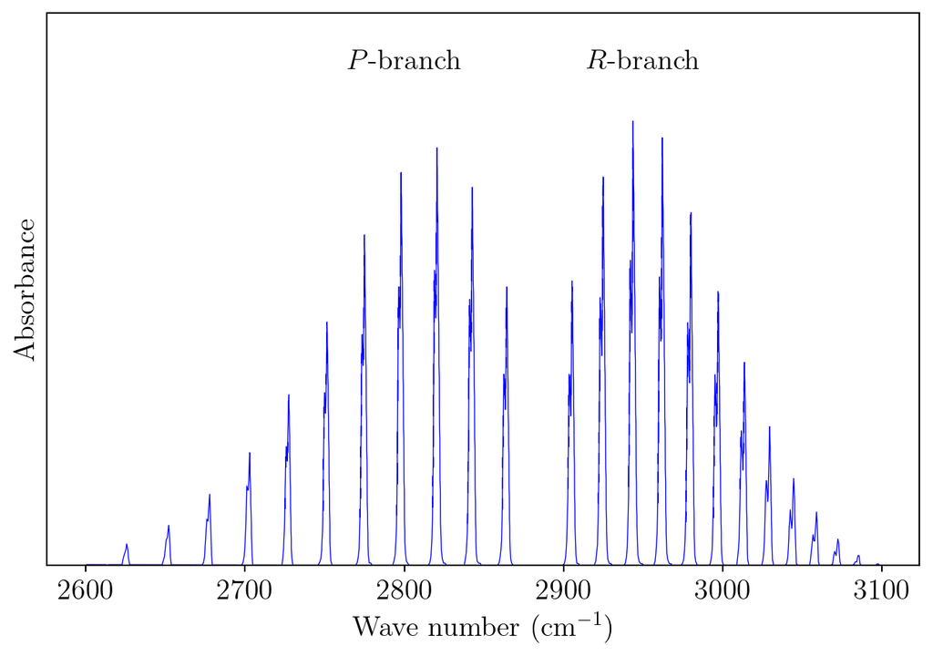

FTIR spectrum of HCl showing P-branch and R-branch.

```python
import numpy as np
import matplotlib.pyplot as plt
from scipy.interpolate import interp1d

plt.rcParams['text.usetex'] = True
plt.rcParams['font.family'] = 'serif'
plt.rcParams['font.size'] = 15

# --- Load benchmark data ---

def load_curve(filename):
    # Allow any whitespace as separator
    data = np.loadtxt(filename, delimiter=',', comments='#')
    # Handle possible extra columns (some files have >2)
    E = data[:, 0]
    I = data[:, 1]
    return E, I


# Example: you must supply these files
E, I = load_curve('./HCl.csv')


# --- Plotting ---
fig, ax = plt.subplots(figsize=(7,5))

ax.plot(E, np.maximum(I-0.07,0), label=r'spectrum', color='b', lw=0.5)

ax.set_xlabel(r'Wave number (cm$^{-1}$)')
ax.set_ylabel(r'Absorbance')
ax.text(2800, 10.5, r'$P$-branch', ha='center', va='center', fontsize=15)
ax.text(2950, 10.5, r'$R$-branch', ha='center', va='center', fontsize=15)

ax.set_yticks([])

#ax.set_xlim([0, 2.5])
ax.set_ylim([0, 11.5])

plt.tight_layout()
plt.show()
```

### Analysis of Line Positions

For a transition $v_i \to v_k$ with simultaneous rotational transition $J_i \to J_k$, the photon energy is:

$$h\nu = E(v_k, J_k) - E(v_i, J_i)$$

For the fundamental vibrational transition ($v = 0 \to v = 1$) in the ground electronic state:

**R-branch** ($\Delta J = +1$, $J_k = J_i + 1$):

$$\nu_R(J) = \nu_0 + B_1(J+1)(J+2) - B_0 J(J+1) = \nu_0 + 2B_1 + (3B_1 - B_0)J + (B_1 - B_0)J^2$$

**P-branch** ($\Delta J = -1$, $J_k = J_i - 1$):

$$\nu_P(J) = \nu_0 + B_1 J(J-1) - B_0 J(J+1) = \nu_0 - (B_1 + B_0)J + (B_1 - B_0)J^2$$

where:  
- $\nu_0 = \omega_e(1 - 2\chi_e)$ is the band origin (pure vibrational frequency)  
- $B_0$ and $B_1$ are the rotational constants for $v = 0$ and $v = 1$, respectively  
- $J$ denotes the initial rotational quantum number $J_i$

### Key Spectroscopic Features

From the HCl spectrum, we can observe:

1. **Line spacing**: The spacing between adjacent lines in each branch is approximately $2B$ (the rotational constant)
2. **Band center gap**: No transition appears at $\nu_0$ due to the $\Delta J = 0$ selection rule
3. **Asymmetry**: The R-branch and P-branch are not perfectly symmetric due to:
   - Vibration-rotation coupling: $B_1 < B_0$ (typically $B_1 \approx B_0 - \alpha_e$)
   - Centrifugal distortion effects
4. **Isotope splitting**: HCl naturally contains two isotopes ($^{35}$Cl and $^{37}$Cl in roughly 3:1 ratio). Each line appears as a doublet because:
   - Different reduced masses: $\mu_{35} \neq \mu_{37}$
   - Different rotational constants: $B \propto 1/\mu$
   - Slightly different vibrational frequencies: $\omega \propto 1/\sqrt{\mu}$
5. **Line intensity variation**: The intensity of rotational lines depends on:
   - The Boltzmann population of the initial state: $\propto (2J+1)e^{-E(J)/k_BT}$
   - The transition dipole moment squared: $|M_{ik}|^2 \propto J$ or $(J+1)$

   This leads to a maximum intensity at intermediate $J$ values, with intensity falling off at high $J$ due to decreasing thermal population.

Modern **Fourier Transform Infrared (FTIR) spectrometers** with resolutions better than 0.1 cm⁻¹ can resolve individual rotational lines, allowing precise determination of these quantities.

# 3. Raman Spectroscopy

In **Raman spectroscopy**, molecular transitions are induced not by direct absorption but by **inelastic scattering** of photons. When a photon interacts with a molecule, it can exchange energy with a **vibrational or rotational mode**:

- **Stokes line:** scattered photon loses energy (molecule gains vibrational energy)
- **Anti-Stokes line:** scattered photon gains energy (molecule loses vibrational energy)

The **selection rule** arises from the requirement that the **molecular polarizability** changes during the nuclear motion:

$$\Delta \alpha \neq 0$$

Hence, even molecules without a permanent dipole moment (e.g., N$_2$, O$_2$) can be Raman active.

[figure not shown]

Figure 3: Raman energy level diagram illustrating Stokes and anti-Stokes scattering.  
*(Image: Dake / Wikimedia Commons, [CC BY-SA 3.0](https://creativecommons.org/licenses/by-sa/3.0/), [source file](https://commons.wikimedia.org/wiki/File:Raman_energy_levels.svg))*

## 3.1 IR vs. Raman Activity

| Spectroscopy Type | Transition Mechanism | Selection Rule | Example Active Molecules |
| --- | --- | --- | --- |
| Infrared (IR) | Interaction with electric field via permanent dipole | Electronic state must have $\mu(R)\neq 0$; vibrational/rotational motion modulates dipole | HCl, CO |
| Raman | Interaction with electric field via induced dipole (polarizability) | $\Delta \alpha \neq 0$ | N$_2$, O$_2$, CO$_2$ |

> **Notes:**
> - In IR spectroscopy, **vibrational and rotational transitions** within a given electronic state are allowed only if the molecule has a **nonzero permanent dipole moment** in that state. Homonuclear diatomics (H$_2$, N$_2$, O$_2$) are inactive.
> - Raman transitions are complementary: they can occur even if the permanent dipole is zero, provided that the **polarizability changes with nuclear motion**.

## 3.2 Polarizability and the Origin of Raman Scattering

In Raman scattering, the **electric field of the incident light** induces an **oscillating dipole moment** in the molecule. If the molecule’s **polarizability** depends on its **nuclear configuration**, this induced dipole can oscillate not only at the frequency of the incoming light but also at **shifted frequencies** corresponding to molecular vibrations.

The **induced dipole moment** is given by

$$\vec p_{\rm ind}(t) = \alpha(t) \, \vec E(t),$$

where $\alpha$ is the molecular **polarizability tensor** and $\vec E(t)$ the electric field of the light wave. For a monochromatic field,

$$\vec E(t) = \vec E_0 \cos(\omega_{\rm in} t).$$

### Vibrational Dependence of Polarizability

The polarizability depends on the molecular geometry and thus on the **normal coordinates** $Q_k$ of the vibrations:

$$\alpha = \alpha_0 + \sum_k \left( \frac{\partial \alpha}{\partial Q_k} \right)_0 Q_k + \dots$$

**NoteNormal Coordinates**

The complex, coupled motion of all atoms in a molecule can be mathematically simplified using **normal coordinates** ($Q_k$). These coordinates represent **independent, fundamental vibrational modes** where all atoms move in-phase and oscillate at a single, characteristic frequency ($\omega_k$).

If we approximate one vibrational mode as

$$Q_k(t) = Q_{k0} \cos(\omega_k t),$$

then inserting this into the first-order expansion gives

$$\alpha(t) = \alpha_0 + \left( \frac{\partial \alpha}{\partial Q_k} \right)_0 Q_{k0} \cos(\omega_k t).$$

Combining this with $\vec E(t)$ yields an induced dipole moment that oscillates at **sum and difference frequencies**:

$$\vec p_{\rm ind}(t) =
\underbrace{\alpha_0 \vec E_0 \cos(\omega_{\rm in} t)}_{\text{Rayleigh scattering}}
+
\underbrace{\frac{1}{2} \left( \frac{\partial \alpha}{\partial Q_k} \right)_0 Q_{k0} \vec E_0
\left[ \cos((\omega_{\rm in} + \omega_k)t) + \cos((\omega_{\rm in} - \omega_k)t) \right]}_{\text{Raman scattering (Stokes and anti-Stokes)}}.$$

- The **first term** corresponds to **elastic (Rayleigh)** scattering.
- The **second term** leads to **frequency-shifted components** at $\omega_{\rm in} \pm \omega_k$, corresponding to **Raman lines**.

A vibrational mode $Q_k$ is **Raman active** if its motion changes the polarizability, i.e.

$$\left( \frac{\partial \alpha}{\partial Q_k} \right)_0 \neq 0.$$

### Quantum-Mechanical Picture

In quantum terms, Raman scattering is a **second-order transition process** involving a **virtual intermediate state**:

$$M_{fi} \sim
\sum_m
\frac{
\langle f | \vec \mu \cdot \vec E_{\rm out} | m \rangle
\langle m | \vec \mu \cdot \vec E_{\rm in} | i \rangle
}{
E_i + \hbar \omega_{\rm in} - E_m + i\Gamma_m
}.$$

Here:

- $|i\rangle$ and $|f\rangle$ are the initial and final molecular states (differing in vibrational energy).
- $|m\rangle$ is a virtual electronic state.
- $\vec \mu$ is the dipole operator.
- The denominator expresses the **off-resonant nature** of the process.

In the **far off-resonant limit**, this second-order interaction effectively reduces to the **polarizability tensor** $\alpha_{ij}$, connecting the semi-classical and quantum viewpoints.

> **Summary:**  
> Raman scattering arises because molecular vibrations modulate the polarizability, allowing the oscillating induced dipole to reradiate light at shifted frequencies. A mode is Raman active if it changes how the molecule’s electron cloud responds to an electric field.

## 3.3 Relevance of Raman Spectroscopy for Chemistry

Raman spectroscopy is widely used in chemistry for **molecular identification**, **structure determination**, and **reaction monitoring**. It is particularly valuable for **symmetric molecules** that are IR-inactive but Raman-active, providing complementary vibrational information. Raman can probe **bond strengths**, **molecular symmetry**, and **phase changes** in solids, liquids, and gases.

# Key Takeaways

This chapter has introduced the fundamental concepts of **molecular transitions and spectroscopy**, focusing on rotational, vibrational, and electronic degrees of freedom. The following points summarize the essential ideas:

1. **Molecular transitions are quantized:** Molecules can only absorb or emit photons that match the **energy difference** between discrete quantum states.
2. **Transition dipole moments govern intensity:** The **electric dipole operator** $\hat{\vec \mu}$ determines which transitions are allowed; the square of the matrix element $|M_{ik}|^2$ controls the spectral intensity.
3. **Decomposition into electronic and nuclear contributions:** Using the **Born–Oppenheimer approximation**, the transition dipole separates into an **electronic integral** and a **nuclear integral**, giving rise to **Franck–Condon factors** for vibronic transitions.
4. **Selection rules arise from symmetry and angular momentum:**
   - **Electronic transitions:** $\Delta S = 0$, $\Delta \Lambda = 0, \pm1$, $\Delta J_{\rm tot} = 0, \pm1$, parity change required for homonuclear molecules.
   - **Vibrational transitions:** Typically $\Delta v = \pm1$ (fundamental), with weaker overtones for $\Delta v = \pm2, \pm3, \dots$
   - **Rotational transitions:** $\Delta J = \pm1$ (P and R branches); $\Delta J = 0$ forbidden for $\Sigma$ states.
5. **Permanent dipoles vs. polarizability:**
   - **Infrared (IR) activity** requires a **nonzero permanent dipole moment**. Homonuclear diatomics (H₂, N₂, O₂) are IR-inactive.
   - **Raman activity** requires a **change in polarizability**; even molecules without a permanent dipole can be Raman-active.
6. **Rovibrational spectroscopy provides structural insights:** Line positions, branch patterns, and intensities reveal **bond lengths, force constants, isotopic composition, and rotational constants**.
7. **Practical relevance:**
   - **Chemical analysis:** Identification of molecules, determination of bond strengths, and monitoring of reactions.
   - **Environmental impact:** CO₂ and H₂O absorb IR radiation via rovibrational transitions, underlying the **greenhouse effect**.
   - **Complementarity of IR and Raman:** Combining both techniques gives a more complete picture of molecular vibrations, especially for symmetric or nonpolar molecules.

**Summary:** Understanding the decomposition of the transition dipole, the resulting selection rules, and the interplay between permanent dipoles and polarizability provides a **coherent framework** for predicting and interpreting molecular spectra across IR, Raman, and electronic transitions.